# REGRESIONES MULTIPLES

Lluis Albareda Dauder

22/3/2021

DESCARGA DE LIBRERIAS

```r
function_install_packages <- function(x)
{
  for(i in x)
  {
    if(!require(i, character.only = TRUE))
    {
      install.packages(i, dependencies = TRUE)
      require(i, character.only = TRUE)
    }
  }
}

function_install_packages(c('dplyr', 'ggplot2', 'corrplot', 'ggcorrplot', 'e1071', 'GGally', 'tidyverse', 'ggpubr', 'base', 'car', 'MASS', 'leaps', 'hier.part', 'gvlma', 'lmtest', 'readxl', 'qqplotr'))
```

LECTURA DE DATOS

```r
USA <- as.data.frame(state.x77)
```

Nuestro data frame inicial tiene un total de 8 variables numericas con 50 filas.

```r
str(USA)
```

```
## 'data.frame':    50 obs. of  8 variables:
##  $ Population: num  3615 365 2212 2110 21198 ...
##  $ Income    : num  3624 6315 4530 3378 5114 ...
##  $ Illiteracy: num  2.1 1.5 1.8 1.9 1.1 0.7 1.1 0.9 1.3 2 ...
##  $ Life Exp  : num  69 69.3 70.5 70.7 71.7 ...
##  $ Murder    : num  15.1 11.3 7.8 10.1 10.3 6.8 3.1 6.2 10.7 13.9 ...
##  $ HS Grad   : num  41.3 66.7 58.1 39.9 62.6 63.9 56 54.6 52.6 40.6 ...
##  $ Frost     : num  20 152 15 65 20 166 139 103 11 60 ...
##  $ Area      : num  50708 566432 113417 51945 156361 ...
```

```r
options(scipen = 100)
```

Una vez analizadas todas las variables de nuestra tabla, vemos que la densidad de poblacion no esta entre ellas. Para poder saber la densidad de cada uno de los 50 estados, realizare los siguientes pasos:

1.Transformar la columna Area (actualmente en millas ^2) en Area km ^2.

2.Crear variable densidad que sera = Population / Area en km ^2

```r
#1
USA$Area <- round(USA$Area*2.58999)
#2
USA$Density <- round(USA$Population/USA$Area, digits =2)
```

Una vez tenemos todas las variables necesarias, vemos que las columnas Population, Income y Area (ahora siempre sera en KM ^2) los valores son muy superiores al resto de columnas.

Realizamos el Coeficiente de asimetria fisher para saber si utilizar la funcion log. o la raiz cuadrada para estandarizar las tres variables anteriormente nombradas.

```r
skewness(USA$Population)
```

```
## [1] 1.922251
```

```r
skewness(USA$Income)
```

```
## [1] 0.2046903
```

```r
skewness(USA$Area)
```

```
## [1] 4.098357
```

Las tres variables tienen un coeficiente de asimetria fisher positivo, es decir, valores acumulados por debajo de la media. Income es la que tiene valores acumulados mas cerca de la media, parecido a una dispersion Normal.

En este caso transformamos las tres variables usando la formula log, para poder trabajar mas comodo con ellas y no tener una distorcion originada por la diferencia de valores entre las variables.

```r
USA <- round(transform(USA, Population=log(Population), Income=log(Income), Area=log(Area)), digits = 2)
USA %>% filter(is.na(USA)) %>% count()
```

```
##   n
## 1 0
```

Una vez revisado que no hay ningun NA entre los valores de nuestro data frame, tenemos la tabla lista para poder empezar a analizar los datos.

1- Crear una nueva variable indicando la division de cada estado en un nuevo Data frame llamado USAD:

Creamos una nueva columna con todos los estados dentro del nuevo data frame (USAD), transformamos esta columna en una division segun: NORTHEAST, MIDWEST, SOUTH y WEST.

```r
USAD <- USA
USAD$Division <- row.names(USAD)
USAD$Division <- ifelse(USAD$Division %in% c("Connecticut", "Maine", "Massachusetts", "New Hampshire", "Rhode Island",
                                             "Vermont", "New Jersey", "New York", "Pennsylvania"),                                       "NORTHEAST",

                  ifelse(USAD$Division %in% c("Illinois", "Indiana", "Michigan", "Ohio", "Wisconsin", "Iowa", "Kansas", "Minnesota",
                                             "Missouri", "Nebraska", "North Dakota", "South Dakota"),                                    "MIDWEST",

                  ifelse(USAD$Division %in% c("Delaware", "Florida", "Georgia", "Maryland", "North Carolina", "South Carolina",
                                             "Virginia", "District of Columbia", "West Virginia", "Alabama", "Kentucky",
                                             "Mississippi", "Tennessee", "Arkansas", "Louisiana", "Oklahoma", "Texas"),                  "SOUTH",

                  ifelse(USAD$Division %in% c("Arizona", "Colorado", "Idaho", "Montana", "Nevada", "New Mexico", "Utah", "Wyoming",
                                             "Alaska", "California", "Hawaii", "Oregon", "Washington"),                                  "WEST",

                                                                                                                                         "NULL"))))


table(USAD$Division, useNA = "always")
```

```
##
##   MIDWEST NORTHEAST     SOUTH      WEST      <NA>
##        12         9        16        13         0
```

```r
sum(table(USAD$Division)) == nrow(USA)
```

```
## [1] TRUE
```

Todos los estados han estado divididos en una sola division, en una de las 4 divisiones (MIDWEST, NORTHEAST, SOUTH AND WEST).

2- Analisis de correlaciones y estudio descriptivo de las variables.

Hacemos un analisis descriptivo de las variables:

```r
sd(USA$Population)/mean(USA$Population)
```

```
## [1] 0.1324251
```

```r
sd(USA$Income)/mean(USA$Income)
```

```
## [1] 0.0166774
```

```r
sd(USA$Illiteracy)/mean(USA$Illiteracy)
```

```
## [1] 0.5209685
```

```r
sd(USA$Life.Exp)/mean(USA$Life.Exp)
```

```
## [1] 0.01893934
```

```r
sd(USA$Murder)/mean(USA$Murder)
```

```
## [1] 0.5003442
```

```r
sd(USA$HS.Grad)/mean(USA$HS.Grad)
```

```
## [1] 0.1520863
```

```r
sd(USA$Frost)/mean(USA$Frost)
```

```
## [1] 0.4976149
```

```r
sd(USA$Area)/mean(USA$Area)
```

```
## [1] 0.1005639
```

```r
sd(USA$Density)/mean(USA$Density)
```

```
## [1] 1.491217
```

Variables con alta representacion de la media: Income, Life.Exp, Area

Variables con relativa representacion de la media: Hs.Grad, Population

Variables con baja o pobre representacion de la media: Murder, Frost

Variables con escasa representacion de la media: Illiteracy

Variables con Nula representacion de la media: Density

```r
skewness(USA$Population)
```

```
## [1] -0.07166759
```

```r
skewness(USA$Income)
```

```
## [1] -0.2055453
```

```r
skewness(USA$Illiteracy)
```

```
## [1] 0.8185809
```

```r
skewness(USA$Life.Exp)
```

```
## [1] -0.1534995
```

```r
skewness(USA$Murder)
```

```
## [1] 0.1293391
```

```r
skewness(USA$HS.Grad)
```

```
## [1] -0.3192442
```

```r
skewness(USA$Frost)
```

```
## [1] -0.3663767
```

```r
skewness(USA$Area)
```

```
## [1] -1.051653
```

```r
skewness(USA$Density)
```

```
## [1] 2.366435
```

Variables con valores acumulados por debajo de la media: Illiteracy, Murder, Density

Variables con valores acumulados por encima de la media: Income, Life.Exp, Hs.Grad, Frost, Area

Variables con valores acumulados cerca de la media: Population

```r
kurtosis(USA$Population)
```

```
## [1] -0.8786403
```

```r
kurtosis(USA$Income)
```

```
## [1] -0.1992509
```

```r
kurtosis(USA$Illiteracy)
```

```
## [1] -0.4714226
```

```r
kurtosis(USA$Life.Exp)
```

```
## [1] -0.6690728
```

```r
kurtosis(USA$Murder)
```

```
## [1] -1.211198
```

```r
kurtosis(USA$HS.Grad)
```

```
## [1] -0.8779262
```

```r
kurtosis(USA$Frost)
```

```
## [1] -0.9438373
```

```r
kurtosis(USA$Area)
```

```
## [1] 1.431788
```

```r
kurtosis(USA$Density)
```

```
## [1] 5.007554
```

Forma Leptocurtica: Area, Density

Forma Platicurtica: Population, Illiteracy, Life.Exp, Murder, Hs.Grad, Frost, Income

Creamos una tabla de correlaciones entre todas las variables:

```r
cor(USA)
```

```
##             Population      Income   Illiteracy    Life.Exp     Murder
## Population  1.00000000  0.05865495  0.215831851 -0.10863731  0.3593673
## Income      0.05865495  1.00000000 -0.477405020  0.37637973 -0.2571848
## Illiteracy  0.21583185 -0.47740502  1.000000000 -0.58847793  0.7029752
## Life.Exp   -0.10863731  0.37637973 -0.588477926  1.00000000 -0.7808458
## Murder      0.35936727 -0.25718484  0.702975199 -0.78084575  1.0000000
## HS.Grad    -0.32190524  0.63177239 -0.657188609  0.58221620 -0.4879710
## Frost      -0.45803275  0.22836793 -0.671946968  0.26206801 -0.5388834
## Area        0.08463899 -0.01928272  0.007937491 -0.10873543  0.2962953
## Density     0.29090433  0.32861579  0.012629563  0.09064475 -0.1797414
##                HS.Grad        Frost         Area      Density
## Population -0.32190524 -0.458032752  0.084638990  0.290904328
## Income      0.63177239  0.228367934 -0.019282720  0.328615795
## Illiteracy -0.65718861 -0.671946968  0.007937491  0.012629563
## Life.Exp    0.58221620  0.262068011 -0.108735432  0.090644750
## Murder     -0.48797102 -0.538883437  0.296295340 -0.179741356
## HS.Grad     1.00000000  0.366779702  0.196681297 -0.090280340
## Frost       0.36677970  1.000000000 -0.021124698 -0.005141295
## Area        0.19668130 -0.021124698  1.000000000 -0.701240230
## Density    -0.09028034 -0.005141295 -0.701240230  1.000000000
```

Correlacion esperanza de vida vs. el resto de variables:

```r
Correlacion_life.exp <- as.data.frame(cor(USA))
Correlacion_life.exp[c("Life.Exp")]
```

```
##               Life.Exp
## Population -0.10863731
## Income      0.37637973
## Illiteracy -0.58847793
## Life.Exp    1.00000000
## Murder     -0.78084575
## HS.Grad     0.58221620
## Frost       0.26206801
## Area       -0.10873543
## Density     0.09064475
```

Hay un total de 4 correlaciones positivas y 4 negativas. Entre ellas destacamos la alta correlacion negativa entre el ratio de asesinatos vs esperanza de vida, la correlacion netagiva entre el porcentaje de analfabetismo y la esperanza de vida y finalmente la correlacion positiva entre el volumen de universitarios y la esperanza de vida.

Diagramas de dispersión entre todos los pares de variables.

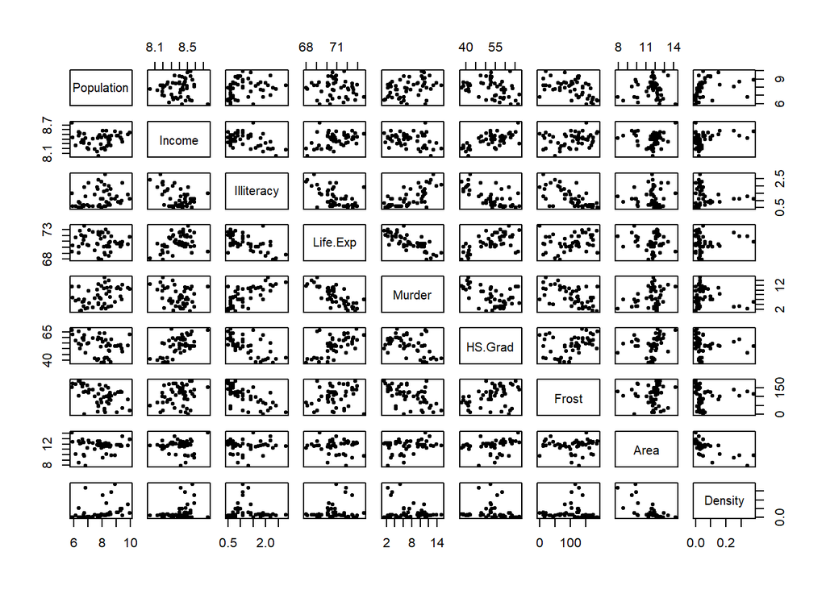

```r
pairs(USA, pch=20)
```

Sobre la correlacion de las variables vs. esperanza de vida, se intuye a traves del grafico la existencia de la correlacion antes comentada.

Una vez revisado el grafico, podemos pensar que existe algun tipo de relacion entre: Population - Frost, Income - Murder, Income - Hs.Grad, Illiteracy - Murder, Illiteracy - Hs. Grad, Illiteracy - Frost, Murder - Hs.Grad y Murder - Frost.

Realizamos una grafica de correlacion marcando con colores mas oscuros las correlaciones mas fuertes.

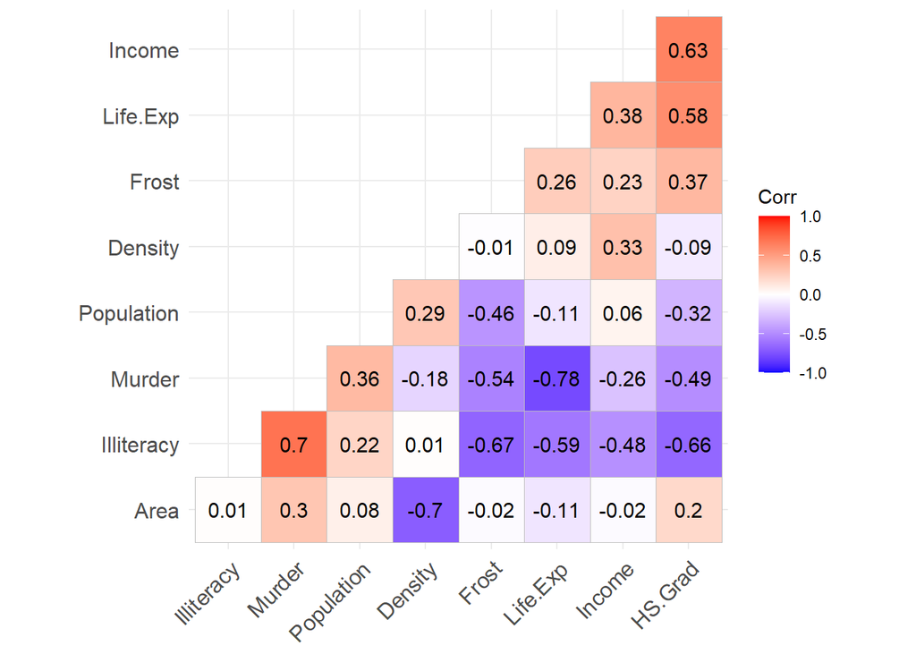

```r
ggcorrplot(cor(USA[ , seq(1:9)], use="complete.obs"), hc.order=TRUE, type="lower", lab=TRUE)
```

Las parejas con correlaciones mas altas son:

1. Murder - Life.exp : -0,78
2. Illiteracy - Murder : 0,7
3. Density - Area : -0,7
4. Illiteracy - Frost: -0,67
5. Illiteracy - Hs. Grad: -0,66

Con el grafico de dispersion entre variables habiamos intuido un total de 8 correlaciones, pero la tercera correlacion mas fuerte era mas complicada de ver, por lo tanto, es muy importante, siempre analizar las correlaciones porque a simple vista con el diagrama de dispersion no todas las correlaciones son senzillas de ver.

Analizando los estadísticos de posición, dispersión y forma ayudan a conocer las correlaciones entre las variables. Distinta forma de dispersion, es decir, que una de las variables tenga los valores acumulados por debajo de la media y la otra por encima de la media, denotan una correlacion negativa entre las variables. Si las dos variables tienen una dispersion muy parecida, denota que en caso de que exista correlacion, sera positiva. La forma es un buen indicador de que una variable pueda variar sistematicamente con respecto a la otra, por lo tanto, que exista correlacion.

Las tres correlaciones mas fuertes:

-Murder - Life.esp: tienen una dispersion totalmente distina, murder tiene los valores acumulados por debajo de la media y la esperanza de vida por encima de la media, denota correlacion negativa. La forma platicurtica bastante parecida.

-Illiteracy - Murder: tienen una dispersion muy parecida, y una forma similar, esto ayuda a entender que tengan una correlacion positiva fuerte.

-Densidad - Area: Tienen una dispersion distinta y una forma muy Leptocurtica, esto se transforma en una correlacion negativa fuerte. En este caso, estas dos variables, que son cuya forma es distinta al resto de variables, no guardan ninguna relacion mas.

Con este analisis podemos concluir que los estadisticos de posicion, dispersion y forma, nos ayudan a entender y a preveer que variables pueden tener relaciones fuertes y cuales no.

Hacemos un analisis avanzado de estadistica descriptiva y correlaciones entre esperanza de vida y las tres variables que tenian mas correlacion con la esperanza de vida desglosado segun division de los estados:

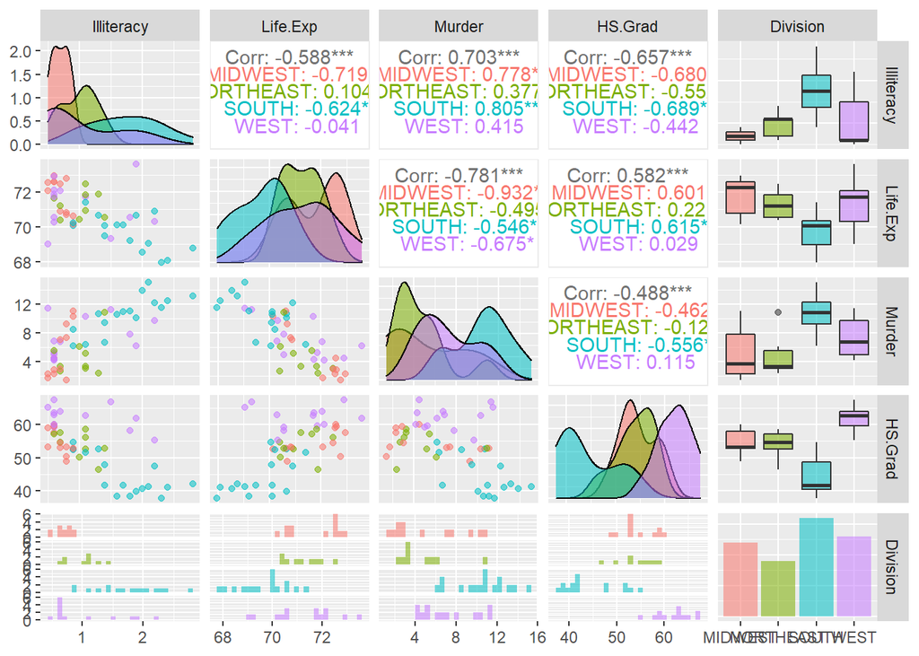

```r
ggpairs(USAD[ , c(3,4,5,6, 10)], aes(colour = USAD$Division, alpha = 0.5), upper = list(continuous = wrap("cor", alignPercent = 0.5)))
```

Las divisiones muestran que aunque hemos cogido varigables correlacionadas entre si, hay divisiones por estado con correlaciones muy altas y otras muy bajas.

La esperanza de vida tiene correlacion con las variables asesinatos, volumen de universitarios y porcentaje analfabetismo, pero esto no significa que en nuestro modelo predictivo que construiremos mas adelante no tenga otras variables utiles para explicar la esperanza de vida, pero esto tampoco significa que las tres variables nombradas sean utiles para explicar la esperanza de vida, es dedir, hay alguna pareja de estas tres variables con correlaciones que pueden ser lo suficientemente fuertes como para debilitar nuestro modelo de regresion lineal multiple.

Una vez analizado como afectan las divisiones de los estados en nuestras variables mas relacionadas con la esperanza de vida, nos indica que tambien podremos utilizar las divisiones para intentar perfeccionar nuestras predicciones. Hay divisiones de estado con correlaciones muy altas, en especial, la esperanza de vida del MIDWEST con los asesinatos de dicha division.

3- Modelo de regresion lineal multiple:

```r
modelo1 <-lm(Life.Exp ~ Population + Income + Illiteracy + Murder + HS.Grad + Frost + Area + Density, data = USA)
modelo1
```

```
##
## Call:
## lm(formula = Life.Exp ~ Population + Income + Illiteracy + Murder +
##     HS.Grad + Frost + Area + Density, data = USA)
##
## Coefficients:
## (Intercept)   Population       Income   Illiteracy       Murder      HS.Grad
##   60.641911     0.380822     0.975827     0.349156    -0.324653     0.053980
##       Frost         Area      Density
##   -0.003171    -0.110616    -3.594127
```

Nuestro modelo de regresion lineal multiple que relaciona la esperanza de vida con el resto de variables de la talba USA es=

60,64 + (Population * 0,38) + (Income * 0,98) + (Illiteracy * 0,35) + (Murder * -0,32) + (HS.Grad * 0,05) + (Frost * -0,003) + (Area * -0,11) + (Density * -3,59) + RESIDUO

Graficamos la media de la bondad del ajuste con Root - Mean - Square Prediction error:

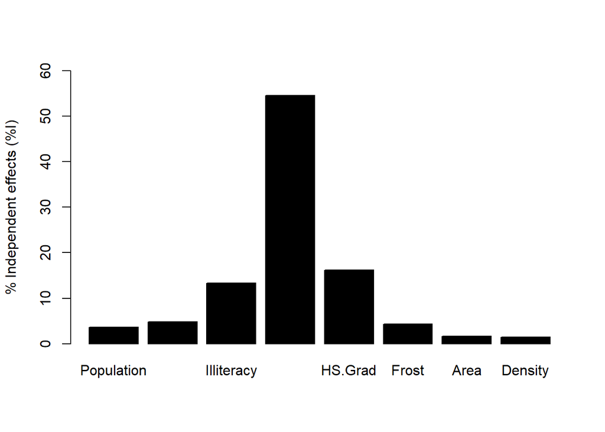

```r
relat.imp.RMSPE=hier.part(USA$Life.Exp, USA[, c(1,2,3,5,6,7,8,9)],
                          family="gaussian", gof="RMSPE", barplot=TRUE)
```

Population -> 3.63 %  
Income -> 4.85 %  
Illiteracy -> 13.33%  
Murder -> 54.58%  
HS.Grad -> 16.14%  
Frost -> 4.36 %  
Area -> 1.69 %  
Density -> 1.42 %

Dentro de las 8 variables usadas en nuestro model de regresion lineal multiple, destacamos la variable MURDER con un 54.58 %, es el predictor con mayor importancia relativa comparado con el resto de variables de nuestro modelo inical. Las siguientes variables con un valor mas elevado son ILLITERACY y HS.Grad, yendo acorde con los comentarios anteriores sobre las correlaciones existentes entre estas 3 variables y la esperanza de vida.

Ahora evaluaremos el ajuste global de nuestro modelo, la bondad del ajuste y que variables contribuyen a la prediccion en nuestro modelo:

```r
summary(modelo1)
```

```
##
## Call:
## lm(formula = Life.Exp ~ Population + Income + Illiteracy + Murder +
##     HS.Grad + Frost + Area + Density, data = USA)
##
## Residuals:
##      Min       1Q   Median       3Q      Max
## -1.43925 -0.37745 -0.04107  0.59440  1.33860
##
## Coefficients:
##              Estimate Std. Error t value     Pr(>|t|)
## (Intercept) 60.641911   9.360016   6.479 0.0000000902 ***
## Population   0.380822   0.163531   2.329       0.0249 *
## Income       0.975827   1.209518   0.807       0.4244
## Illiteracy   0.349156   0.380956   0.917       0.3648
## Murder      -0.324653   0.047383  -6.852 0.0000000267 ***
## HS.Grad      0.053980   0.024642   2.191       0.0342 *
## Frost       -0.003171   0.003375  -0.940       0.3529
## Area        -0.110616   0.166816  -0.663       0.5110
## Density     -3.594127   2.459885  -1.461       0.1516
## ---
## Signif. codes:  0 '***' 0.001 '**' 0.01 '*' 0.05 '.' 0.1 ' ' 1
##
## Residual standard error: 0.7241 on 41 degrees of freedom
## Multiple R-squared:  0.7566, Adjusted R-squared:  0.7091
## F-statistic: 15.93 on 8 and 41 DF,  p-value: 0.0000000002264
```

El F-statistic tambien conocido como el F-test, nos muestra que F(8,41) = 15,93 por lo que alguna de nuestras variables es significativa en el modelo anterior. El p-value es practicamente nulo (0.0000000002264), con lo que nuestros resultados son significativos, es decir, el modelo es significativo.

El R^2 de nuestro modelo es medianamente alto = 0,71 Este dato lo podemos traducir: Un 71 % de la variabilidad de la esperanza de vida, queda explicada por la variabilidad del resto de variables de nuestro modelo predictivo.

La variable estrella de nuestro modelo, como no, es el ratio de asesinatos y homicidios por 100.000 habitantes, tiene un p-valor = 0.0000000267 muy por debajo de 0.05, dicha variable es muy significativa.

El intercepto es muy significativo, el segundo valor mas significativo de nuestro modelo. El valor del intercepto es de 60.64, es decir, si todas las variables fueran 0 y el residuo tambien, el resultado de la esperanza de vida seria de 60.64 años. La esperanza de vida subira dependiendo de si las variables con valores mas grandes son: Population, Income, Illiteracy o Hs.Grad. La esperanza de vida se reducira en caso de que las variables con valores altos sean: Murder, Frost, Area y Density, sobretodo en el caso de la densidad de poblacion.

Population tiene un P-Value = 0.0249 < 0.05, es una variable significativa. Tiene una correlacion negativa de -0.11, a primera vista, es una de las variables que hemos descartado por la poca correlacion que guarda con la esperanza de vida, pero al no tener una relacion fuerte con otra variable, es dedir, no queda explicada dentro de ninguna otra variable y tiene un poco de relacion con Murder ( nuestra variable estrella ) aporta valor en nuestro modelo de regresion.

El volumen de universitarios tambien aporta valor en el modelo1 con un p-valor un poco por debajo de 0.05. ¿Porque HS.Grad es mas significativo que Illiteracy si antes hemos visto que Illiteracy tiene una mayor correlacion con la esperanza de vida? En el caso de Illiteracy, queda explicado con MURDER (tienen mucha correlacion) y al tener relacion tambien con HS.Grad, Illiteracy no aporta mucho valor en nuestro modelo, por eso esta entre las 3 variables con p-valores mayores.

La densidad tiene un p-valor de 0.15 > 0.05, en este caso no aporta valor en nuestro modelo, dicha variable, que esta muy correlacionada con la area, hace que la superficie del estado sea la variable con menos valor.

Income y Frost son otras variables con p-valores superirores a 0.05 con lo que en el modelo actual, no aportan valor significativo para predecir la esperanza de vida. Ambos valores tienen correlacion con variables que SI aportan en nuestro modelo, por lo que entendemos que income y frost estan explicadas por otras variables.

Para mejorar el modelo actual, deberiamos ir quitando las variables con p-valores mas altos para ir ajustando el R^2 y ganar bondad del ajuste para tener un porcentaje mayor y asi poder predecir la esperanza de vida con mayor notariedad.

4- Procedemos a realizar un proceso step para seleccionar las variables mas representativas:

Modelo step con las ocho variables para predecir la esperanza de vida:

```r
step(modelo1, direction = "backward")
```

```
## Start:  AIC=-24.21
## Life.Exp ~ Population + Income + Illiteracy + Murder + HS.Grad +
##     Frost + Area + Density
##
##              Df Sum of Sq    RSS     AIC
## - Area        1    0.2305 21.726 -25.675
## - Income      1    0.3413 21.837 -25.421
## - Illiteracy  1    0.4404 21.936 -25.195
## - Frost       1    0.4628 21.959 -25.143
## <none>                    21.496 -24.209
## - Density     1    1.1192 22.615 -23.671
## - HS.Grad     1    2.5158 24.012 -20.674
## - Population  1    2.8432 24.339 -19.997
## - Murder      1   24.6128 46.109  11.949
##
## Step:  AIC=-25.68
## Life.Exp ~ Population + Income + Illiteracy + Murder + HS.Grad +
##     Frost + Density
##
##              Df Sum of Sq    RSS     AIC
## - Income      1    0.2772 22.003 -27.041
## - Illiteracy  1    0.2992 22.025 -26.991
## - Frost       1    0.8416 22.568 -25.775
## <none>                    21.726 -25.675
## - Density     1    1.1311 22.857 -25.137
## - HS.Grad     1    2.2958 24.022 -22.653
## - Population  1    2.8613 24.588 -21.489
## - Murder      1   25.7295 47.456  11.389
##
## Step:  AIC=-27.04
## Life.Exp ~ Population + Illiteracy + Murder + HS.Grad + Frost +
##     Density
##
##              Df Sum of Sq    RSS     AIC
## - Illiteracy  1    0.2040 22.207 -28.580
## - Frost       1    0.8207 22.824 -27.210
## - Density     1    0.8540 22.857 -27.137
## <none>                    22.003 -27.041
## - Population  1    3.1561 25.159 -22.339
## - HS.Grad     1    5.3418 27.345 -18.174
## - Murder      1   26.4335 48.437  10.412
##
## Step:  AIC=-28.58
## Life.Exp ~ Population + Murder + HS.Grad + Frost + Density
##
##              Df Sum of Sq    RSS     AIC
## - Density     1     0.702 22.910 -29.023
## <none>                    22.207 -28.580
## - Frost       1     2.155 24.362 -25.949
## - Population  1     3.111 25.318 -24.025
## - HS.Grad     1     6.146 28.353 -18.364
## - Murder      1    33.688 55.895  15.573
##
## Step:  AIC=-29.02
## Life.Exp ~ Population + Murder + HS.Grad + Frost
##
##              Df Sum of Sq    RSS     AIC
## <none>                    22.910 -29.023
## - Frost       1     2.210 25.120 -26.418
## - Population  1     2.462 25.372 -25.920
## - HS.Grad     1     6.961 29.871 -17.757
## - Murder      1    34.110 57.019  14.569
```

```
##
## Call:
## lm(formula = Life.Exp ~ Population + Murder + HS.Grad + Frost,
##     data = USA)
##
## Coefficients:
## (Intercept)   Population       Murder      HS.Grad        Frost
##    68.71519      0.24747     -0.29001      0.05456     -0.00517
```

Modelo con Population, Murder, Hs.Grad y Frost:

```r
modeloSTEP <-lm(Life.Exp ~ Population + Murder + HS.Grad + Frost, data = USA)
summary(modeloSTEP)
```

```
##
## Call:
## lm(formula = Life.Exp ~ Population + Murder + HS.Grad + Frost,
##     data = USA)
##
## Residuals:
##      Min       1Q   Median       3Q      Max
## -1.41646 -0.43824  0.02493  0.52101  1.63045
##
## Coefficients:
##              Estimate Std. Error t value             Pr(>|t|)
## (Intercept) 68.715192   1.416543  48.509 < 0.0000000000000002 ***
## Population   0.247465   0.112535   2.199             0.033058 *
## Murder      -0.290010   0.035431  -8.185       0.000000000186 ***
## HS.Grad      0.054557   0.014754   3.698             0.000589 ***
## Frost       -0.005170   0.002481  -2.084             0.042915 *
## ---
## Signif. codes:  0 '***' 0.001 '**' 0.01 '*' 0.05 '.' 0.1 ' ' 1
##
## Residual standard error: 0.7135 on 45 degrees of freedom
## Multiple R-squared:  0.7405, Adjusted R-squared:  0.7175
## F-statistic: 32.11 on 4 and 45 DF,  p-value: 0.000000000001157
```

Al quitar todas las variables con P-VALUE > 0.05 conseguimos un R^2 de 0.717 un poco superior a nuestro primer modelo con las 8 variables. Primer modelo= 0.7091 < 0.717 = ModeloSTEP

¿Es este el mejor model teniendo en cuenta las 8 variables?

Si realizamo un resumen de la evolucion sufrida por el R-cuadrado ajustado de las variables predictoras:

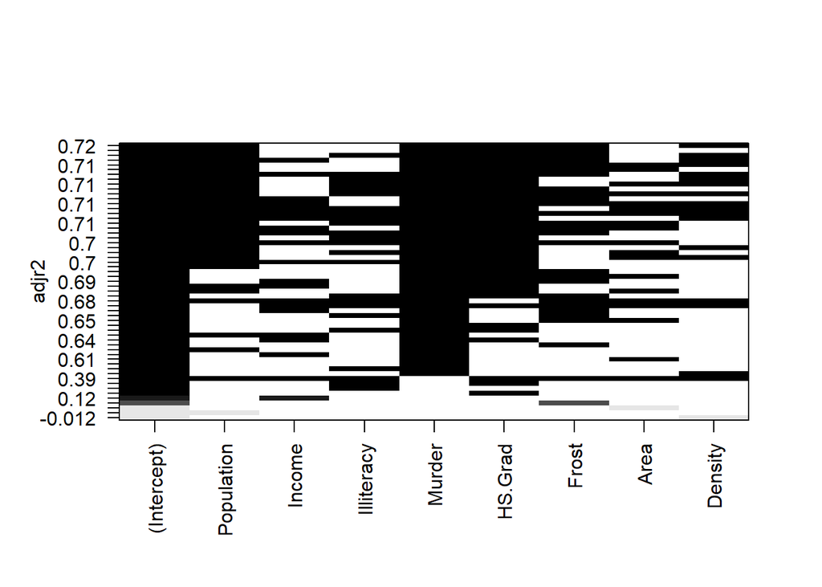

```r
REGRESION_SALTOS <-regsubsets(Life.Exp ~ Population + Income + Illiteracy + Murder + HS.Grad + Frost + Area + Density , data = USA, nbest = 8)
plot(REGRESION_SALTOS, scale = "adjr2")
```

Vemos que si a nuestro modelo STEP le añadimos Density, ganamos un poco de R^2.

```r
modelo8final <-lm(Life.Exp ~ Population + Murder + HS.Grad + Frost + Density, data = USA)
summary(modelo8final)
```

```
##
## Call:
## lm(formula = Life.Exp ~ Population + Murder + HS.Grad + Frost +
##     Density, data = USA)
##
## Residuals:
##      Min       1Q   Median       3Q      Max
## -1.51003 -0.41415 -0.03688  0.54171  1.68689
##
## Coefficients:
##              Estimate Std. Error t value             Pr(>|t|)
## (Intercept) 68.651704   1.411446  48.639 < 0.0000000000000002 ***
## Population   0.297297   0.119747   2.483              0.01692 *
## Murder      -0.303949   0.037204  -8.170        0.00000000023 ***
## HS.Grad      0.051873   0.014865   3.490              0.00111 **
## Frost       -0.005106   0.002471  -2.066              0.04471 *
## Density     -1.555211   1.318365  -1.180              0.24448
## ---
## Signif. codes:  0 '***' 0.001 '**' 0.01 '*' 0.05 '.' 0.1 ' ' 1
##
## Residual standard error: 0.7104 on 44 degrees of freedom
## Multiple R-squared:  0.7485, Adjusted R-squared:  0.7199
## F-statistic: 26.19 on 5 and 44 DF,  p-value: 0.000000000003619
```

En este caso, el modelo8final = 0.7199 > modelo STEP = 0.717

Si añadimos la densidad a nuestro modelo, el modelo sigue siendo significativo pero en este caso ganamos en bondad del ajuste.

Comparacion modelo8final vs modelo STEP

```r
anova(modelo8final, modeloSTEP)
```

```
## Analysis of Variance Table
##
## Model 1: Life.Exp ~ Population + Murder + HS.Grad + Frost + Density
## Model 2: Life.Exp ~ Population + Murder + HS.Grad + Frost
##   Res.Df    RSS Df Sum of Sq      F Pr(>F)
## 1     44 22.207
## 2     45 22.910 -1  -0.70235 1.3916 0.2445
```

No eliminar la densidad no hace que el modelo deje de ser significativo, el p-valor global continua siendo muy bajo, y la bondad del ajuste ahora es un poco mas grande.

Vamos a crear un modelo muy parecido al modelo1, pero en este caso añadimos la division por estados:

```r
modeloD1 <-lm(Life.Exp ~ Population + Income + Illiteracy + Murder + HS.Grad + Frost + Area + Density + Division, data = USAD)
summary(modeloD1)
```

```
##
## Call:
## lm(formula = Life.Exp ~ Population + Income + Illiteracy + Murder +
##     HS.Grad + Frost + Area + Density + Division, data = USAD)
##
## Residuals:
##      Min       1Q   Median       3Q      Max
## -1.20660 -0.44386 -0.04253  0.51660  1.22105
##
## Coefficients:
##                    Estimate Std. Error t value     Pr(>|t|)
## (Intercept)       66.987712  10.064735   6.656 0.0000000722 ***
## Population         0.311003   0.198477   1.567       0.1254
## Income             0.299297   1.307037   0.229       0.8201
## Illiteracy         0.400151   0.389742   1.027       0.3110
## Murder            -0.301004   0.052884  -5.692 0.0000015073 ***
## HS.Grad            0.062200   0.035118   1.771       0.0846 .
## Frost             -0.003984   0.004105  -0.971       0.3378
## Area              -0.144772   0.183900  -0.787       0.4360
## Density           -1.979655   2.761285  -0.717       0.4778
## DivisionNORTHEAST -0.693415   0.443061  -1.565       0.1259
## DivisionSOUTH     -0.554823   0.456809  -1.215       0.2320
## DivisionWEST      -0.390791   0.492843  -0.793       0.4327
## ---
## Signif. codes:  0 '***' 0.001 '**' 0.01 '*' 0.05 '.' 0.1 ' ' 1
##
## Residual standard error: 0.7235 on 38 degrees of freedom
## Multiple R-squared:  0.7747, Adjusted R-squared:  0.7095
## F-statistic: 11.88 on 11 and 38 DF,  p-value: 0.000000003368
```

Vemos la evolucion sufrida por el Adjusted R-squared de las variables:

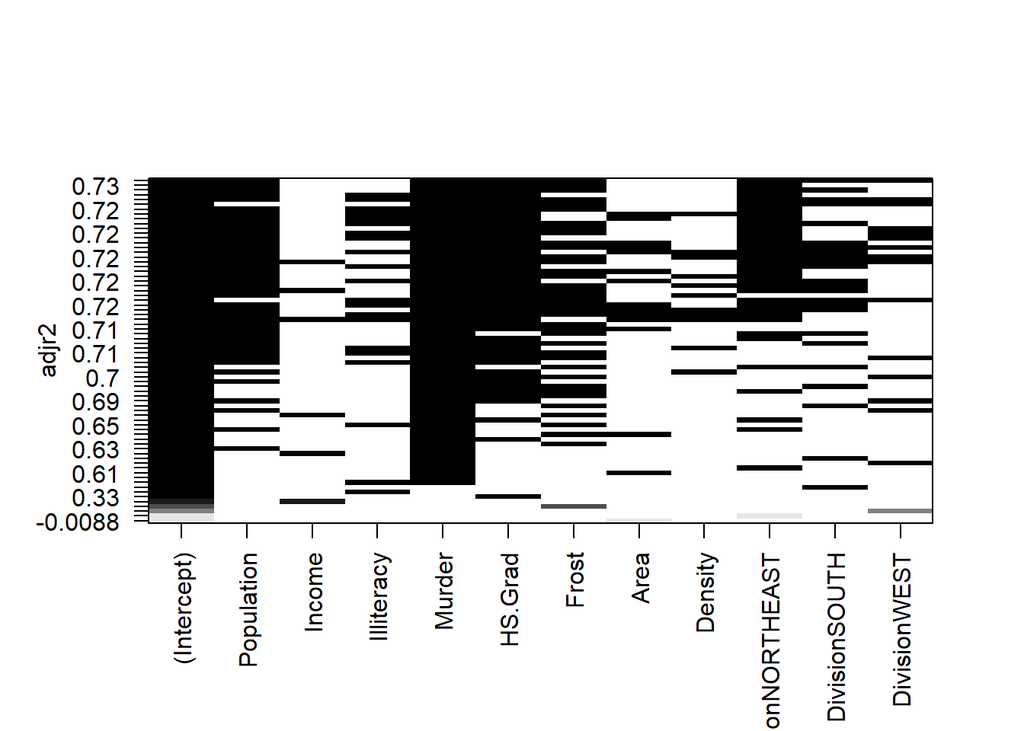

```r
REGRESION_SALTOSD <-regsubsets(Life.Exp ~ Population + Income + Illiteracy + Murder + HS.Grad + Frost + Area + Density + Division, data = USAD, nbest = 9)
plot(REGRESION_SALTOSD, scale = "adjr2")
```

Creamos el modelo con el R^2 mayor de todos:

```r
modeloDfinal <-lm(Life.Exp ~ Murder + HS.Grad + Frost + Population + Division, data = USAD)
summary(modeloDfinal)
```

```
##
## Call:
## lm(formula = Life.Exp ~ Murder + HS.Grad + Frost + Population +
##     Division, data = USAD)
##
## Residuals:
##      Min       1Q   Median       3Q      Max
## -1.11624 -0.45652 -0.02077  0.43322  1.44906
##
## Coefficients:
##                    Estimate Std. Error t value             Pr(>|t|)
## (Intercept)       70.042677   1.854730  37.764 < 0.0000000000000002 ***
## Murder            -0.278593   0.041956  -6.640         0.0000000476 ***
## HS.Grad            0.051620   0.024721   2.088               0.0429 *
## Frost             -0.006979   0.003011  -2.318               0.0254 *
## Population         0.165980   0.140954   1.178               0.2456
## DivisionNORTHEAST -0.639478   0.311678  -2.052               0.0465 *
## DivisionSOUTH     -0.579008   0.435551  -1.329               0.1909
## DivisionWEST      -0.483426   0.438620  -1.102               0.2767
## ---
## Signif. codes:  0 '***' 0.001 '**' 0.01 '*' 0.05 '.' 0.1 ' ' 1
##
## Residual standard error: 0.7003 on 42 degrees of freedom
## Multiple R-squared:  0.7668, Adjusted R-squared:  0.7279
## F-statistic: 19.72 on 7 and 42 DF,  p-value: 0.00000000002094
```

Nuestro modelo final, es el que contiene: Murder, HS.Grad, Frost, Population y Division. Modelo final = 0.7279 > 0.7199 = Modelo 8 final

Quitando la densidad y añadiendo las divisiones por estado, tenemos un modelo significativo con un F-Statistic: ( 7 , 42 ) = 19.72 y p-valor practicamente nulo. Es el modelo con el R^2 mayor, de 0.7279

Una de las caracteristicas mas llamativas de este modelo, es que la variable mas significativa es el Intercepto, con un valor de 70.04 (en el resto de modelos el intercepto es menor) y el resto de variables en su mayoria van reduciendo el intercepto para ajustar la prediccion.

Histograma de la importancia relativa de cada variable de nuestro modelo final:

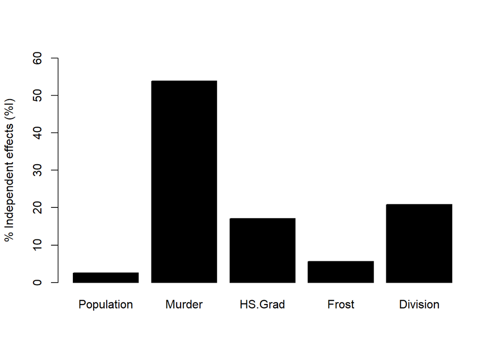

```
## $gfs
##  [1] 9.396755 9.341140 5.870377 7.639881 9.068333 7.338732 5.609157 7.599764
##  [9] 9.067532 7.331856 5.456222 5.597026 5.427469 7.624144 6.765027 7.264201
## [17] 5.011965 5.465439 4.982432 7.551126 6.765025 7.168857 5.037025 5.259190
## [25] 4.867566 6.591289 4.786414 4.819655 4.767898 6.497353 4.612457 4.538152
##
## $IJ
##                     I           J       Total
## Population -0.1252637  0.06964858 -0.05561514
## Murder     -2.6174834 -0.90889438 -3.52637782
## HS.Grad    -0.8304702 -0.92640346 -1.75687363
## Frost      -0.2718441 -0.05657809 -0.32842216
## Division   -1.0135416 -1.04448133 -2.05802289
##
## $I.perc
##            ind.exp.var
## Population    2.578184
## Murder       53.873170
## HS.Grad      17.092777
## Frost         5.595108
## Division     20.860761
##
## $params
## $params$full.model
## [1] "y ~ Population + Murder + HS.Grad + Frost + Division"
##
## $params$family
## [1] "gaussian"
##
## $params$link
## [1] "default"
##
## $params$gof
## [1] "RMSPE"
```

```r
(relat.imp.RMSPE = hier.part(USAD$Life.Exp, USAD[ , c('Population', 'Murder', 'HS.Grad', 'Frost', 'Division')], family = "gaussian", gof = "RMSPE", barplot = TRUE))
```

Murder es la variable que mas aporta a nuestro R^2, en segunda posicion nos encontramos con la variable Division. Un 20% del R^2 es explicado por la variabilidad de divisiones por estado. Finalmente, la variable menos representativa en el R^2 es la Population.

Modelo final segun division:

Life.Exp[MIDWEST] = -0.27 * Mur. + 0.05 * Hs. - 0.007 * Frost + 0.17 * Pop. + 70.04

Life.Exp[NORTHEAST] = -0.27 * Mur. + 0.05 * Hs. - 0.007 * Frost + 0.17 * Pop. + 69.40

Life.Exp[SOUTH] = -0.27 * Mur. + 0.05 * Hs. - 0.007 * Frost + 0.17 * Pop. + 69.46

Life.Exp[WEST] = -0.27 * Mur. + 0.05 * Hs. - 0.007 * Frost + 0.17 * Pop. + 69.56

Podemos decir, que en caso de que todas las variables fueran iguales, segun nuestro modelo predictivo, en el MIDWEST seria donde la esperanza de vida es mayor que el resto de divisiones, despues seria la division WEST, SOUTH y finalmente la division del NORTHEAST serian pronosticados con una esperanza de vida un poco menor que el resto.

Si dejamos las variables Hs.Grad y Population iguales para todos, los estados con mas asesinatos y a la vez, con mas dias con temperatura de congelacion, tendran segun nuestro modelo, menos esperanza de vida.

Si dejamos las variables Frost y Murder iguales para todos, los estados con mas volumen de universitarios y con una poblacion elevada, tendran segun nuestro modelo, mayor esperanza de vida.

Intervalos de confianza al 95% para los coeficientes de las variables predictoras de nuestro modelo final:

```r
confint(lm(Life.Exp ~ Murder + HS.Grad + Frost + Population + Division, data = USAD))
```

```
##                          2.5 %        97.5 %
## (Intercept)       66.299681190 73.7856729143
## Murder            -0.363263262 -0.1939236725
## HS.Grad            0.001731105  0.1015090829
## Frost             -0.013055308 -0.0009024285
## Population        -0.118476731  0.4504375657
## DivisionNORTHEAST -1.268469247 -0.0104871677
## DivisionSOUTH     -1.457984931  0.2999683502
## DivisionWEST      -1.368596819  0.4017451935
```

En terminos de inferencia estadistica, podemos determinar, que a un 95% de confianza, la mayoria de nuestras variables no contienen el valor 0 en el intervalo de confianza, es decir, la mayoria de nuestras variables, con otras observaciones, aportan en el modelo predictivo.

Las variables Population, divisionsouth y division west si contienen el valor 0 en el intervalo. A un 95% de confianza, estas tres variables con otras observaciones, no aportarian valor al modelo predictivo.

5- Diagnostico del modelo final:

Hacemos un grafico de Residuos tipificados/ Valores pronosticados tipificados para comprobar la hipotesis de linealidad y de homocedasticidad para estudiar si nuestro modelo es adecuado. En caso de que en nuestro grafico podamos observar alguna tendencia, esto nos indica que puede existir autocorrelacion, heterocedasticidad o falta de linealidad en nuestros residuos. Si eso pasara, nos indicaria que nuestro modelo predictivo no es tan bueno como pensamos y podria afectar en sus capacidades predictivas.

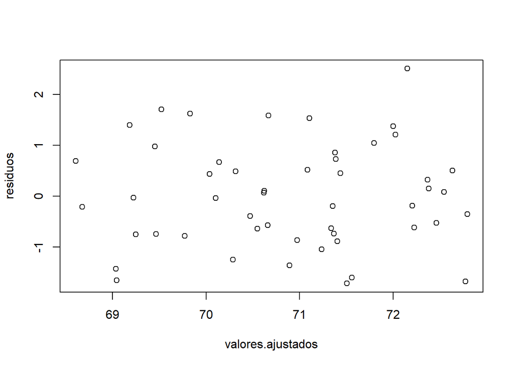

```r
residuos<- rstandard(modeloDfinal)
valores.ajustados<-fitted(modeloDfinal)
plot(valores.ajustados, residuos)
```

Los residuos en gran parte estan situados entre -2 y 2, indicando que no hay mucha dispersion entre ellos, si el intervalo fuera mayor, indicaria que la diferencia entre prediccion y realidad es grande, cosa que no pasa en nuestro modelo.

No podemos observar ninguna tendencia en los residuos, por lo que la homocedasticidad y la linealidad (residuos independientes) parece una hipotesis razonable.

Dibujamos el grafico Q-Q Plot, donde enfrentamos los percentiles de las variables. En caso de que los puntos esten muy alienados con la linea de los quantiles, podriamos pensar que nuestro model de regresion lineal multiple es Normal.

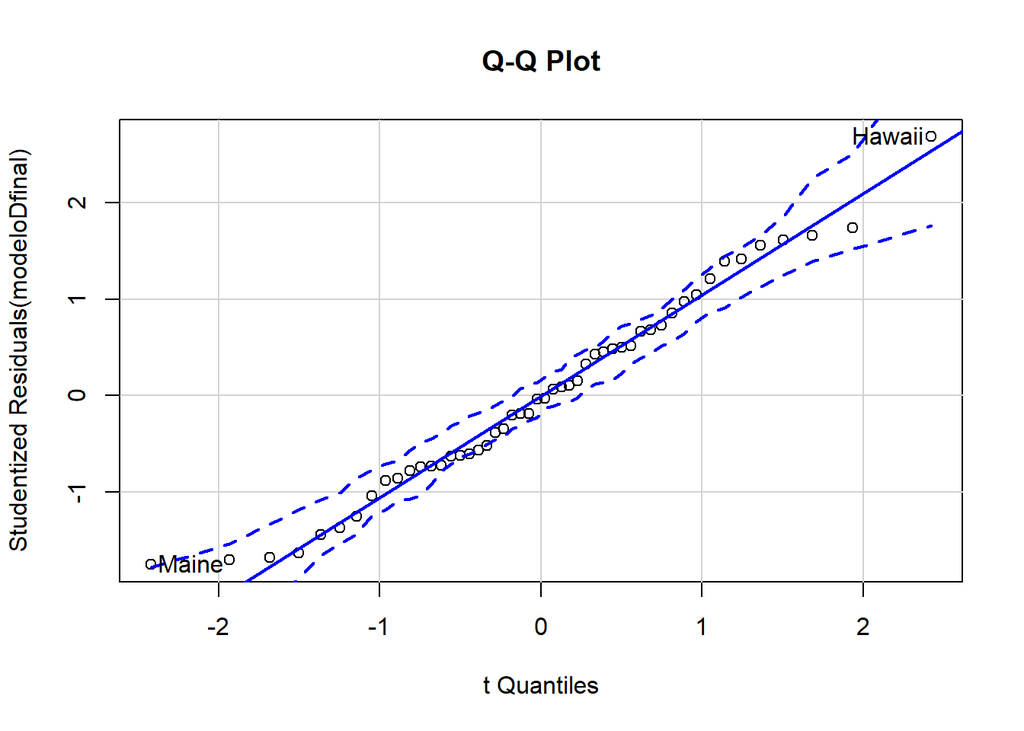

```
## Hawaii  Maine
##     11     19
```

```r
qqPlot(modeloDfinal, labels = row.names(USAD), id.method = "identify", simulate = TRUE, main = "Q-Q Plot")
```

La linea muestra la probabilidad observada y esperada bajo normalidad. Hay dos estados con percentiles un poco mas dispersos de lo normal ( Maine y Hawaii), pero en general, todos los puntos caen muy cerca de la distribucion ideal de los residuos. La normalidad de los residuos parece una hipotesis muy razonable.

```r
skewness(residuos)
```

```
## [1] 0.232872
```

```r
kurtosis(residuos)
```

```
## [1] -0.7072429
```

Los residuos estan acumulados un poco por debajo de la media, estan cerca de tener una dispersion normal. La forma de los residuos es Platicurtica.

Una vez analizados los residuos del modelo predictivo final, hacemos los siguientes Test para determinar un diagnostico del modelo:

-Test de Breusch - Pagan:

```r
bptest(modeloDfinal)
```

```
##
##  studentized Breusch-Pagan test
##
## data:  modeloDfinal
## BP = 13.771, df = 7, p-value = 0.0554
```

El p-valor es = 0.0554 > 0.05 No rechazamos la hipotesis inicial de Homocedasticidad. Al tener un P-valor muy cercano a 0.05 podemos considerar que el modelo no es muy Homodecastico.

Nuestro modelo presenta que la varianza del error condicionado a las variables explicativas de nuestro modelo, es constante a lo largo de las observaciones y comun.

-Test de Shapiro - Wilk:

```r
shapiro.test(modeloDfinal$residuals)
```

```
##
##  Shapiro-Wilk normality test
##
## data:  modeloDfinal$residuals
## W = 0.97756, p-value = 0.4545
```

El p-value = 0.4545 > 0.05 No rechazamos la hipotesis nula de normalidad.

Nuestros residuos tienen una distribucion NORMAL, tal y como habiamos esperado con el analisis del Q-Q plot. Aunque los residuos esten acumulados un poco por debajo de la media y la forma sea mas Platicurtica que un modelo de distribucion Normal, los residuos de nuestro modelo se comportan con NORMALIDAD.

Test de Durbin-Watson:

```r
dwtest(modeloDfinal)
```

```
##
##  Durbin-Watson test
##
## data:  modeloDfinal
## DW = 1.7441, p-value = 0.1658
## alternative hypothesis: true autocorrelation is greater than 0
```

El p-valor = 0,1658 > 0,05: No rechazamos H0, por lo que nuestro modelo no presenta autocorrelacion, los valores de la linea de regresion, no presentan dependencia en cuanto al orden de obtención.

Los errores de nuestro modelo no estan correlacionados entre si, por lo que podemos decir que la inferencia estadistica basada en la matriz de varianzas y covarianzas de los estimadores por minimos cuadrados no sera erronea, por lo que los parametros utilizados si seran eficientes en nuestro modelo. Al aceptar que nuestro modelo no presenta autocorrelacion, se satisface el supuesto del modelo lineal.

Los residuos no son dependientes entre si.

```r
bgtest(modeloDfinal,order = 2)
```

```
##
##  Breusch-Godfrey test for serial correlation of order up to 2
##
## data:  modeloDfinal
## LM test = 1.1321, df = 2, p-value = 0.5678
```

```r
bgtest(modeloDfinal,order = 1)
```

```
##
##  Breusch-Godfrey test for serial correlation of order up to 1
##
## data:  modeloDfinal
## LM test = 0.87178, df = 1, p-value = 0.3505
```

Correlaciones entre las varaibles predictoras menos division:

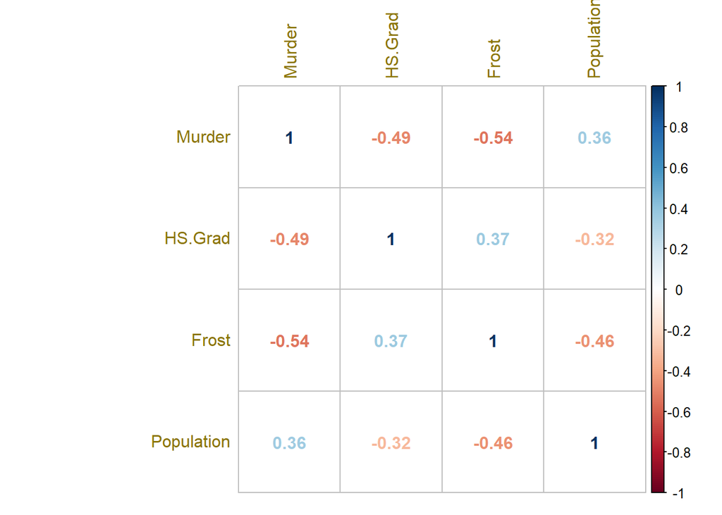

```r
corrplot(cor(dplyr::select(USAD, Murder, HS.Grad, Frost, Population)),
         method = "number", tl.col = "gold4")
```

```r
vif(modeloDfinal)
```

```
##                GVIF Df GVIF^(1/(2*Df))
## Murder     2.397077  1        1.548250
## HS.Grad    3.983998  1        1.995996
## Frost      2.447907  1        1.564579
## Population 2.152369  1        1.467095
## Division   9.743250  3        1.461450
```

Este grado de colinealidad de nuestro modelo, es explicado por tener un alto porcentaje de R-squared y algunas variables no significativas (p-value superior a 0.05) en nuestro modelo.

Al interntar establecer relacion causa-efecto de nuestras variables predictoras con la esperanza de vida, podriamos llegar a conclusiones erroneas creado por la existencia de colinealidad, creiendo que una variable es la causa o varias es la causa la esperanza de vida cuando en realidad es otra o otras. Este especto no debe preocuparnos mucho por el simple hecho que la colinealidad existente es baja.

```r
outlierTest(modeloDfinal)
```

```
## No Studentized residuals with Bonferroni p < 0.05
## Largest |rstudent|:
##        rstudent unadjusted p-value Bonferroni p
## Hawaii 2.686034           0.010392      0.51961
```

Complementamos el estudio anterior con un analisis de Leverages (hat) y de la distancia Cook:

```r
summary(influence.measures(modeloDfinal))
```

```
## Potentially influential observations of
##   lm(formula = Life.Exp ~ Murder + HS.Grad + Frost + Population +      Division, data = USAD) :
##
##        dfb.1_ dfb.Mrdr dfb.HS.G dfb.Frst dfb.Pplt dfb.DNOR dfb.DSOU dfb.DWES
## Hawaii  0.88  -0.01     0.14    -1.58_*  -1.02_*  -0.17    -0.72    -0.35
##        dffit   cov.r cook.d hat
## Hawaii  1.84_*  0.49  0.37   0.32
```

En la tabla anterior, se recoge que las observaciones ( en nuestro caso tan solo Hawaii ) que son significativamente influyentes en al menos uno de los predictores.

Para Hawaii detectamos que es influyente variables Frost y Population. Es el unico estado con 0 dias a temperatura de congelacion y a la vez con poca poblacion. La gran mayoria de estados con pocos dias de congelacion, tienen poblaciones bastante por encima.

Para Leverages se consideraria influyente aquella cuyo el valor Hat es superior a = 2.5((p + 1)/n), siendo p el numero de predictores y n las observaciones. Teniendo un total de 7 predictores y 50 observaciones, el valor Hat de Hawaii deberia ser menor a 0.4, en nuestro caso es correcto. El valor Hat de Hawaii = 0.32 < 0.4.

Segun la distancia de Cook se consideraria influyente con un valor superior a 1, en nuestro caso es 0.37.

El outlier Hawaii, es un valor anomalo que influye a nuestro modelo predictivo, pero no excede los limites de preocupacion segun la distancia Cook y el valor Leverages.

Visualizacion de las influencias:

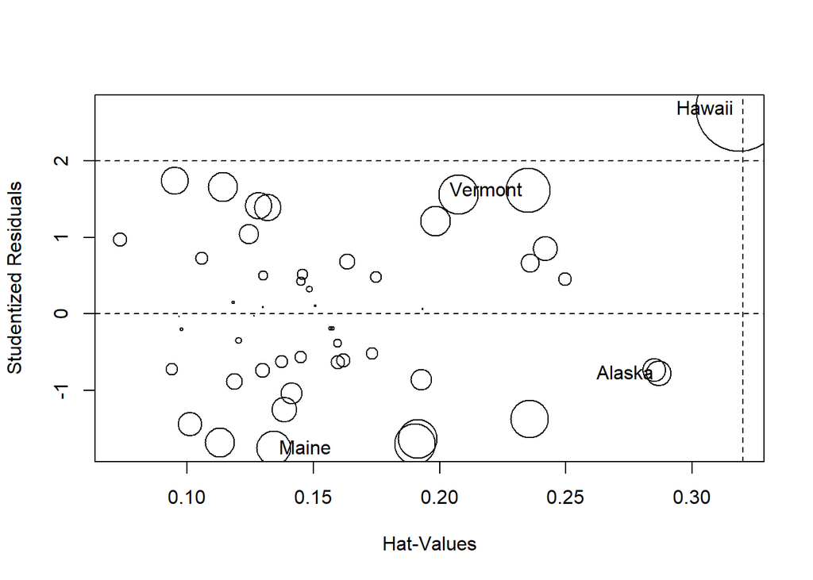

```
##            StudRes       Hat      CookD
## Alaska  -0.7788006 0.2868954 0.03079078
## Hawaii   2.6860343 0.3186505 0.36740647
## Maine   -1.7549529 0.1341004 0.05680839
## Vermont  1.6164549 0.2349730 0.09660788
```

```r
influencePlot(modeloDfinal)
```

Podemos ver la influencia de Hawaii en nuestro modelo cuyos valores son superiores al resto de observaciones.

Usamos la funcion GVLMA para finalizar con el diagnostico de nuestro modelo predictivo:

```r
gvlma(modeloDfinal)
```

```
##
## Call:
## lm(formula = Life.Exp ~ Murder + HS.Grad + Frost + Population +
##     Division, data = USAD)
##
## Coefficients:
##       (Intercept)             Murder            HS.Grad              Frost
##         70.042677          -0.278593           0.051620          -0.006979
##        Population  DivisionNORTHEAST      DivisionSOUTH       DivisionWEST
##          0.165980          -0.639478          -0.579008          -0.483426
##
##
## ASSESSMENT OF THE LINEAR MODEL ASSUMPTIONS
## USING THE GLOBAL TEST ON 4 DEGREES-OF-FREEDOM:
## Level of Significance =  0.05
##
## Call:
##  gvlma(x = modeloDfinal)
##
##                      Value p-value                Decision
## Global Stat        1.58734  0.8111 Assumptions acceptable.
## Skewness           0.27126  0.6025 Assumptions acceptable.
## Kurtosis           1.16998  0.2794 Assumptions acceptable.
## Link Function      0.04297  0.8358 Assumptions acceptable.
## Heteroscedasticity 0.10313  0.7481 Assumptions acceptable.
```

Todos los supuestos son aceptables, por lo que el modelo predictivo es valido al cumplirse todos los supuestos necesarios.

Global Stat: Aceptamos la hipotesis inicial, linealidad entre las variables del modelo.

Skewness: Aceptamos la hipotesis inicial, Se cumple el supuesto de normalidad debido a una simetria significativa.

Kurtosis: Aceptamos la hipotesis inicial, aceptamos normalidad debido a la inexistencia de una curtosis significativa.

Link Function: Aceptamos la hipotesis inicial, nuestro modelo es adecuado para indicar la esperanza de vida.

Heteroscedasticy: Aceptamos hipotesis inicial, hay homocedasticidad entre variables.

Una vez hemos realizado un diagnostico completo de nuestro modelo, podemos concluir que nuestro modelo es bueno para determinar la esperanza de vida.

¿Podemos mejorar el modelo?

Antes hemos detectado la existencia de la observacion Hawaii como outlier en nuestro modelo. Si creamos una nueva tabla sin dicha observacion:

```r
USAD.ajustado <- USAD[-11,]
```

Realiamos el mismo modeloDfinal pero con la nueva tabla:

```r
modeloDfinal_ajustado <-lm(Life.Exp ~ Murder + HS.Grad + Population + Division + Frost, data = USAD.ajustado)
summary(modeloDfinal_ajustado)
```

```
##
## Call:
## lm(formula = Life.Exp ~ Murder + HS.Grad + Population + Division +
##     Frost, data = USAD.ajustado)
##
## Residuals:
##      Min       1Q   Median       3Q      Max
## -1.10763 -0.48017 -0.05798  0.43780  1.18494
##
## Coefficients:
##                    Estimate Std. Error t value             Pr(>|t|)
## (Intercept)       68.514862   1.822126  37.602 < 0.0000000000000002 ***
## Murder            -0.278362   0.039158  -7.109         0.0000000116 ***
## HS.Grad            0.048327   0.023105   2.092               0.0427 *
## Population         0.300019   0.140703   2.132               0.0390 *
## DivisionNORTHEAST -0.589515   0.291492  -2.022               0.0497 *
## DivisionSOUTH     -0.287122   0.420786  -0.682               0.4989
## DivisionWEST      -0.338361   0.412924  -0.819               0.4173
## Frost             -0.002533   0.003261  -0.777               0.4419
## ---
## Signif. codes:  0 '***' 0.001 '**' 0.01 '*' 0.05 '.' 0.1 ' ' 1
##
## Residual standard error: 0.6536 on 41 degrees of freedom
## Multiple R-squared:  0.7831, Adjusted R-squared:  0.7461
## F-statistic: 21.15 on 7 and 41 DF,  p-value: 0.000000000009732
```

Quitamos la variable Frost, al tener un p-value superior a 0.05:

```r
modeloDfinal_ajustado <-lm(Life.Exp ~ Murder + HS.Grad + Population + Division, data = USAD.ajustado)
summary(modeloDfinal_ajustado)
```

```
##
## Call:
## lm(formula = Life.Exp ~ Murder + HS.Grad + Population + Division,
##     data = USAD.ajustado)
##
## Residuals:
##      Min       1Q   Median       3Q      Max
## -1.11237 -0.48844 -0.03903  0.49492  1.20680
##
## Coefficients:
##                   Estimate Std. Error t value             Pr(>|t|)
## (Intercept)       67.74313    1.52006  44.566 < 0.0000000000000002 ***
## Murder            -0.27978    0.03893  -7.187        0.00000000787 ***
## HS.Grad            0.04585    0.02278   2.013              0.05054 .
## Population         0.36928    0.10831   3.409              0.00145 **
## DivisionNORTHEAST -0.56355    0.28820  -1.955              0.05721 .
## DivisionSOUTH     -0.11854    0.35876  -0.330              0.74273
## DivisionWEST      -0.18544    0.36123  -0.513              0.61039
## ---
## Signif. codes:  0 '***' 0.001 '**' 0.01 '*' 0.05 '.' 0.1 ' ' 1
##
## Residual standard error: 0.6505 on 42 degrees of freedom
## Multiple R-squared:  0.7799, Adjusted R-squared:  0.7485
## F-statistic:  24.8 on 6 and 42 DF,  p-value: 0.000000000002472
```

Nuestro modelo a mejorado con notariedad en terminos de R^2, ha pasado de 0.7279 a 0.7485. La nueva bondad del ajuste es mas alta.

Realizamos un gvlma test para determinar como se han visto modificados los resultados del nuevo modelo:

```r
gvlma(modeloDfinal_ajustado)
```

```
##
## Call:
## lm(formula = Life.Exp ~ Murder + HS.Grad + Population + Division,
##     data = USAD.ajustado)
##
## Coefficients:
##       (Intercept)             Murder            HS.Grad         Population
##          67.74313           -0.27978            0.04585            0.36928
## DivisionNORTHEAST      DivisionSOUTH       DivisionWEST
##          -0.56355           -0.11854           -0.18544
##
##
## ASSESSMENT OF THE LINEAR MODEL ASSUMPTIONS
## USING THE GLOBAL TEST ON 4 DEGREES-OF-FREEDOM:
## Level of Significance =  0.05
##
## Call:
##  gvlma(x = modeloDfinal_ajustado)
##
##                      Value p-value                Decision
## Global Stat        2.51375  0.6422 Assumptions acceptable.
## Skewness           0.05638  0.8123 Assumptions acceptable.
## Kurtosis           1.88156  0.1702 Assumptions acceptable.
## Link Function      0.21219  0.6451 Assumptions acceptable.
## Heteroscedasticity 0.36361  0.5465 Assumptions acceptable.
```

En el modelo final ajustado sin el outlier Hawaii, a parte de ser un modelo significativo y con una bondad de ajuste del 0.75 (la mas alta de todas).Todos los supuestos son acceptables, por lo que el modelo predictivo es valido al cumplirse todos los supuestos necesarios.

Aunque todas las probabilidades de este nuevo modelo segun el p-valor de cada test indican que es mas que problable aceptar todos los supuestos, este modelo es:

Menos probable a ser lineal que el anterior.

Es mas probable a cumplirse el supuesto de normalidad debido a la existencia de simetria significativa, comparado con el anterior.

Es menos probable a aceptar normalidad debido a la inexistencia de una curtosis significativa, comparado con el anterior.

Es menos probable a ser el modelo mas adecuado para indicar la esperanza de vida, comparado con el anterior.

Es menos probable a aceptar el supuesto de homocedasticidad, comparado con el anterior.

Al ser un modelo muy significativo, con una bondad de ajuste superior al resto y con todos los supuestos aceptados para validar dicho modelo, podemos concluir que el mejor modelo es el siguiente:

Life.Exp[MIDWEST] = -0.28 * Mur. + 0.05 * Hs. + 0.37 * Pop. + 67.74

Life.Exp[NORTHEAST] = -0.28 * Mur. + 0.05 * Hs. + 0.37 * Pop. + 67.18

Life.Exp[SOUTH] = -0.28 * Mur. + 0.05 * Hs. + 0.37 * Pop. + 67.63

Life.Exp[WEST] = -0.27 * Mur. + 0.05 * Hs. + 0.37 * Pop. + 67.56

Con el modelo final ajustado, vemos que los valores estimados Population y el intercepto, son los valores que se han visto mas afectados al ajustar el modelo quitando la observacio Hawaii, tambien, la variable Frost ha caido de nuestro modelo. La estimacion para Population ha subido de 0.17 a 0.37. Justo las dos variables que Hawaii afectaba mas, en caso de population ha augmentado la importancia en nuestro modelo y en el caso de Frost, ha dejado de ser significativa para el modelo. El intercepto tambien se ha visto levemente modificado, se ha reducido en 2.3.

Nuestro modelo final ajustado ha sido afectado en los puntos claves que Hawaii era influyente, al quitar esta observacion hemos equilibrado la estimacion de Population, de esta manera, hemos ganado en bondad del ajuste.